# homework

## Answer

Exercises 6.5:  
According to t-test:$T=\frac{\sqrt{n}(\bar x-\mu)}{s}\sim t(n-1)\\$, we can get the confidence interval of $\mu$ is $\bar x ± t_{1-\alpha/2}(n-1)s/\sqrt n$.

```r
set.seed(111)
m<-10000
n<-20
alpha<-0.05
mu1<-2
p11<-numeric(m)
for(i in 1:m){
 x<-rchisq(n,2)
 c1<-mean(x)+qt(alpha/2,n-1)*sd(x)*n^(-1/2)
 c2<-mean(x)-qt(alpha/2,n-1)*sd(x)*n^(-1/2)
 p11[i]<-as.numeric(c1<=mu1&&mu1<=c2)
}
cp11<-mean(p11)

sigma1<-4
p12<-numeric(m)
for(i in 1:m){
 x<-rchisq(n,2)
 c1<-0
 c2<-(n-1)*(sd(x))^2/qchisq(alpha,n-1)
 p12[i]<-as.numeric(c1<=sigma1&&sigma1<=c2)
}
cp12<-mean(p12)



m<-10000
n<-20
alpha<-0.05
mu2<-0
p21<-numeric(m)
for(i in 1:m){
 x<-rnorm(n,0,2)
 c1<-mean(x)+qt(alpha/2,n-1)*sd(x)*n^(-1/2)
 c2<-mean(x)-qt(alpha/2,n-1)*sd(x)*n^(-1/2)
 p21[i]<-as.numeric(c1<=mu2&&mu2<=c2)
}
cp21<-mean(p21)

sigma2<-4
p22<-numeric(m)
for(i in 1:m){
 x<-rnorm(n,0,2)
 c1<-0
 c2<-(n-1)*(sd(x))^2/qchisq(alpha,n-1)
 p22[i]<-as.numeric(c1<=sigma2&&sigma2<=c2)
}
cp22<-mean(p22)

print(c(cp11,cp21,cp12,cp22))
```

```
## [1] 0.9189 0.9520 0.7807 0.9494
```

The t-interval should be more robust to departures from normality than the interval for variance.

## Answer

Exercises 6.A:
Calculate the 1 err by
$$\frac1m\sum_{j=1}^m I(p_j\le\alpha)$$

```r
set.seed(123)

m<-1000
n<-20
alpha<-0.05
mu1<-1
p1<-numeric(m)
for(i in 1:m){
 x<-rchisq(n,1)
 ttest <- t.test(x, alternative = "two.sided", mu = mu1)
 p1[i]<-ttest$p.value
}
cp1<-mean(p1 < alpha)


m<-1000
n<-20
alpha<-0.05
mu2<-1
p2<-numeric(m)
for(i in 1:m){
 x<-runif(n,0,2)
 ttest <- t.test(x, alternative = "two.sided", mu = mu2)
 p2[i]<-ttest$p.value
}
cp2<-mean(p2 < alpha)


m<-1000
n<-20
alpha<-0.05
mu3<-1
p3<-numeric(m)
for(i in 1:m){
 x<-rexp(n,1)
 ttest <- t.test(x, alternative = "two.sided", mu = mu3)
 p3[i]<-ttest$p.value
}
cp3<-mean(p3 < alpha)

print(c(cp1,cp2,cp3))
```

```
## [1] 0.113 0.056 0.081
```

Use Monte Carlo simulation to investigate whether the empirical Type I error rate of the t-test is approximately equal to the nominal significance level $\alpha$, when the sampled population is non-normal.

## Discussion

If we obtain the powers for two methods under a particular simulation setting with 10,000 experiments: say, 0.651 for one method and 0.676 for another method. Can we say the powers are different at 0.05 level?

- What is the corresponding hypothesis test problem?
- What test should we use? Z-test, two-sample t-test, paired-t test or McNemar test? Why?
- Please provide the least necessary information for hypothesis testing.

## Answer

1.设两种方法得到的power分别为$power_1$和$power_2$，假设检验为：$H_0:power_1=powe_2$,$H_{\alpha}:power_1 \not= powe_2$.  
2.因为该实验是在同一个样本下进行的，所以不适合用two-sample t-test。当样本量足够大时，样本的均值将服从正态分布，所以通过Z-test和paired-t test这两个方法可以得到近似值。McNemar test不需要对样本的分布进行假设，所以可以很好地处理这个假设检验的问题。  
3.根据题意已知样本量和两种方法各自的power,还需要知道这两种方法各自的显著性。

#hw4 ## Question Exercises 6.C (page 180-181, Statistical Computating with R).

## Answer

Example 6.8 (Skewness test of normality):$\alpha=0.05$,$n=10,20,30,50,100,500$

```r
MMST<-function(X){
  d<-dim(X)[1]
  n<-dim(X)[2]
  X_bar<-matrix(rowMeans(X),d,1)
  centralX=X-matrix(rep(X_bar,n),d,n)
  S0<-matrix(0,d,d)
  for(i in 1:n){
    S0<-S0+centralX[,i]%*%t(centralX[,i])
}
  sigma_hat<-S0/n
  b0<-0
  for(i in 1:n){
    for(j in 1:n){
        b0<-b0+(t(centralX[,i])%*%ginv(sigma_hat)%*%centralX[,j])^3
    }
  }
  b<-b0/(n^2)
  T<-n*b/6
  chi<-qchisq(0.95,d*(d+1)*(d+2)/6)
  as.integer(T>chi)
}
```

```r
library(MASS)
set.seed(666)
d<-3
m<-1000
p<-rep(0,m)
mu<-c(0,0,0)
sigma<-matrix(c(1,0,0,0,1,0,0,0,1),3,3)

n1<-10
for(i in 1:m){
  X<-mvrnorm(n1,mu,sigma)
  X<-t(X)
  p[i]<-MMST(X)
}
t1e1<-sum(p)/m

n2<-20
for(i in 1:m){
  X<-mvrnorm(n2,mu,sigma)
  X<-t(X)
  p[i]<-MMST(X)
}
t1e2<-sum(p)/m

n3<-30
for(i in 1:m){
  X<-mvrnorm(n3,mu,sigma)
  X<-t(X)
  p[i]<-MMST(X)
}
t1e3<-sum(p)/m

n4<-50
for(i in 1:m){
  X<-mvrnorm(n4,mu,sigma)
  X<-t(X)
  p[i]<-MMST(X)
}
t1e4<-sum(p)/m

n5<-100
for(i in 1:m){
  X<-mvrnorm(n5,mu,sigma)
  X<-t(X)
  p[i]<-MMST(X)
}
t1e5<-sum(p)/m


m<-100
n6<-500
for(i in 1:m){
  X<-mvrnorm(n6,mu,sigma)
  X<-t(X)
  p[i]<-MMST(X)
}
t1e6<-sum(p)/m

print(c(t1e1,t1e2,t1e3,t1e4,t1e5,t1e6))
```

[output not shown]

Example 6.10 (Power of the skewness test of normality) skewness test： $(1-\epsilon)N(\mu=0,\Sigma=1I_d)+\epsilon N(\mu=0,\Sigma=100I_d)$,$d=3$.

```r
set.seed(1239)
a <-0.1
n <- 30
m <- 100
k<-3
eps <- c(seq(0,0.15,0.01), seq(0.15,1,0.05))
N <- length(eps)
power <- numeric(N)
mu1<-rep(0,3)
s1<-matrix(c(1,0,0,0,1,0,0,0,1),3,3)
mu2<-rep(0,3)
s2<-matrix(c(100,0,0,0,100,0,0,0,100),3,3)

for (j in 1:N) {
  e <- eps[j]
  p <- numeric(m)

  for (i in 1:m) {

    r<-sample(c(0,1),n,replace=TRUE,prob=c(e,1-e))
    z<-matrix(0,k,n)
    for(d in 1:n){
      x1<-MASS::mvrnorm(1,mu1,s1)
      x2<-MASS::mvrnorm(1,mu2,s2)
      z[,d]<-r[d]*x1+(1-r[d])*x2
    }
    p[i]<-MMST(z)
  }
  power[j] <-sum(p)/m
}

plot(eps, power, type = "b",ylim = c(0,1))
abline(h = 0.05, lty = 2)
s <- (power*(1-power) / m)^(1/2)
lines(eps, power+s, lty = 2)
lines(eps, power-s, lty = 2)
```

[output not shown]

#hw5 ## Question Exercises 7.7, 7.8, 7.9, and 7.B (pages 213, Statistical Computating with R)

## Answer

Example 7.7

```r
library(bootstrap)
data<-scor
covscor<-cov(data)
l<-eigen(covscor)$values
theta.hat<-l[1]/sum(l)

B <- 2000 #larger for estimating bias
n <- nrow(data)
theta.b <- numeric(B)
for (b in 1:B) {
  j <- sample(1:n, size = n, replace = TRUE)
  dataj<-data[j,]
  covscorj<-cov(dataj)
  lj<-eigen(covscorj)$values
  theta.b[b]<-lj[1]/sum(lj)
}
bias1 <- mean(theta.b) - theta.hat
se1<-sd(theta.b)
print(c(bias1,se1))
```

```
## [1] 0.0009232631 0.0475768357
```

## Answer

Example 7.8

```r
theta.jack <- numeric(n)
for (i in 1:n){
  datai<-data[-i,]
  covscori<-cov(datai)
  li<-eigen(covscori)$values
  theta.jack[i]<-li[1]/sum(li)
}
bias2 <- (n - 1) * (mean(theta.jack) - theta.hat)
se2 <- sqrt((n-1) *mean((theta.jack - mean(theta.jack))^2))
print(c(bias2,se2))
```

```
## [1] 0.001069139 0.049552307
```

## Answer

Example 7.9

```r
library(boot)
B<-2000
bootfun <- function(data,id){
  x <- data[id,]
  l <- eigen(cov(x))$values
  theta.hat <- l[1] / sum(l)
  return(theta.hat)
}
bootresult <- boot(data = cbind(scor$mec, scor$vec, scor$alg, scor$ana, scor$sta),statistic = bootfun, R = B)
boot.ci(bootresult, conf = 0.95, type = c("perc"," bca"))
```

```
## BOOTSTRAP CONFIDENCE INTERVAL CALCULATIONS
## Based on 2000 bootstrap replicates
##
## CALL :
## boot.ci(boot.out = bootresult, conf = 0.95, type = c("perc",
##     " bca"))
##
## Intervals :
## Level     Percentile
## 95%   ( 0.5198,  0.7082 )
## Calculations and Intervals on Original Scale
```

## Answer

Example 7.B

```r
library(boot)
set.seed(12345)
B<-1000
n<-100
skfun <- function(x,i){
  xbar<-mean(x[i])
  s1<-mean((x[i]-xbar)^3)
  s2<-mean((x[i]-xbar)^2)
  s<-s1/(s2^1.5)
  return(s)
}

sk1<-0
norm1<-basic1<-perc1<-matrix(0,B,2)
for(b in 1:B){
  X1<-rnorm(n,0,1)
  result <- boot(data=X1,statistic=skfun, R=1000)
  C<- boot.ci(result,type=c("norm","basic","perc"))
  norm1[b,]<-C$norm[2:3]
  basic1[b,]<-C$basic[4:5]
  perc1[b,]<-C$percent[4:5]
}
#CP
cat('norm =',mean(norm1[,1]<=sk1 & norm1[,2]>=sk1),
    'basic =',mean(basic1[,1]<=sk1 & basic1[,2]>=sk1),
    'perc =',mean(perc1[,1]<=sk1 & perc1[,2]>=sk1))
```

```
## norm = 0.907 basic = 0.911 perc = 0.932
```

```r
#missing on th left
cat('norm =',mean(norm1[,1]>=sk1),
    'basic =',mean(basic1[,1]>=sk1),
    'perc =',mean(perc1[,1]>=sk1))
```

```
## norm = 0.04 basic = 0.038 perc = 0.032
```

```r
#missing on th right
cat('norm =',mean(norm1[,2]<=sk1),
    'basic =',mean(basic1[,2]<=sk1),
    'perc =',mean(perc1[,2]<=sk1))
```

```
## norm = 0.053 basic = 0.051 perc = 0.036
```

```r
e <- rchisq(1000,5)
sk2<-mean(((e-mean(e))/sd(e))^3)
norm2<-basic2<-perc2<-matrix(0,B,2)
for(b in 1:B){
  X2<-rchisq(n,5)
  result <- boot(data=X2,statistic=skfun, R=1000)
  C<- boot.ci(result,type=c("norm","basic","perc"))
  norm2[b,]<-C$norm[2:3]
  basic2[b,]<-C$basic[4:5]
  perc2[b,]<-C$percent[4:5]
}
#CP
cat('norm =',mean(norm2[,1]<=sk2 & norm2[,2]>=sk2),
    'basic =',mean(basic2[,1]<=sk2 & basic2[,2]>=sk2),
    'perc =',mean(perc2[,1]<=sk2 & perc2[,2]>=sk2))
```

```
## norm = 0.641 basic = 0.627 perc = 0.573
```

```r
#missing on th left
cat('norm =',mean(norm2[,1]>=sk2),
    'basic =',mean(basic2[,1]>=sk2),
    'perc =',mean(perc2[,1]>=sk2))
```

```
## norm = 0.006 basic = 0.019 perc = 0
```

```r
#missing on th right
cat('norm =',mean(norm2[,2]<=sk2),
    'basic =',mean(basic2[,2]<=sk2),
    'perc =',mean(perc2[,2]<=sk2))
```

```
## norm = 0.353 basic = 0.354 perc = 0.427
```

#hw6 ## Question Exercise 8.2 (page 242,Statistical Computating with R).

## Answer

Run with iris:

```r
library(energy)
library(Ball)
library(MASS)
library(RANN)
library(boot)

Spearcor <- function(x, y) {
  x=as.matrix(x);y=as.matrix(y);n=nrow(x); m=nrow(y)
  cor(x,y,method="spearman")
}
Spcor <- function(z, ix, dims) {
  #dims contains dimensions of x and y
  n1 <- dims[1]
  n2 <- dims[2]
  n <- n1 + n2
  x <- z[ , 1:n1] # LEAVE x as is
  y <- z[ix, -(1:n1)] # PERMUTE rows of y
  return(Spearcor(x,y))
}
set.seed(7532)
z <- as.matrix(iris[1:50, 1:4])
boot.obj <- boot(data = z, statistic = Spcor, R = 1000,
                 sim = "permutation", dims = c(2, 2))
tb <- c(boot.obj$t0, boot.obj$t)
pcor <- mean(tb>=tb[1])
cortestp<-cor.test(z[1:50,1:2],z[1:50,3:4],method = "pearson")
pcor
```

```
## [1] 0.02022977
```

```r
cortestp
```

```
##
##  Pearson's product-moment correlation
##
## data:  z[1:50, 1:2] and z[1:50, 3:4]
## t = 21.463, df = 98, p-value < 2.2e-16
## alternative hypothesis: true correlation is not equal to 0
## 95 percent confidence interval:
##  0.8661245 0.9373022
## sample estimates:
##      cor
## 0.908061
```

## Question

Design experiments for evaluating the performance of the NN, energy, and ball methods in various situations.

## Answer

1.Unequal variances and equal expectations:$x\sim N(m_{11},s_{11})$,$y\sim N(m_{12},s_{12})$: $m_{11}=\begin{pmatrix} 1 \\ 1\\ 1 \end{pmatrix}$,$s_{11}=\begin{pmatrix}1 & 0 & 0 \\ 0 & 1 & 0\\ 0 & 0 & 1 \end{pmatrix}$;$m_{11}=\begin{pmatrix} 1 \\ 1\\ 1 \end{pmatrix}$,$s_{12}=\begin{pmatrix}4 & 0 & 0 \\ 0 & 4 & 0\\ 0 & 0 & 3 \end{pmatrix}$

```r
Tn <- function(z, ix, sizes,k) {
  n1 <- sizes[1]; n2 <- sizes[2]; n <- n1 + n2
  if(is.vector(z)) z <- data.frame(z,0);
  z <- z[ix, ];
  NN <- nn2(data=z, k=k+1)
  block1 <- NN$nn.idx[1:n1,-1]
  block2 <- NN$nn.idx[(n1+1):n,-1]
  i1 <- sum(block1 < n1 + 0.5); i2 <- sum(block2 > n1+0.5)
  (i1 + i2) / (k * n)
}
eqdist.nn <- function(z,sizes,k){
  boot.obj <- boot(data=z,statistic=Tn,R=R,
                   sim = "permutation", sizes = sizes,k=k)
  ts <- c(boot.obj$t0,boot.obj$t)
  p.value <- mean(ts>=ts[1])
  list(statistic=ts[1],p.value=p.value)
}

#1
m <- 1000
k<-3
d<-3
set.seed(8675)
n1 <- 15
n2 <- 15
n <- n1+n2
N = c(n1,n2)
R<-1000
m11<-rep(1,d)
s11<-matrix(c(1,0,0,0,1,0,0,0,1),d,d)
m12<-rep(1,d)
s12<-matrix(c(4,0,0,0,4,0,0,0,3),d,d)
p.values <- matrix(NA,m,3)
for(i in 1:m){
  x<-mvrnorm(n1,m11,s11)
  y<-mvrnorm(n2,m12,s12)
  z <- rbind(x,y)
  p.values[i,1] <- eqdist.nn(z,N,k)$p.value
  p.values[i,2] <- eqdist.etest(z,sizes=N,R=R)$p.value
  p.values[i,3] <- bd.test(x=x,y=y,num.permutations=R,seed=i*2468)$p.value
}
alpha <- 0.05
pow1 <- colMeans(p.values<alpha)
pow1
```

```
## [1] 0.380 0.392 0.921
```

ball is better.

2.Unequal variances and unequal expectations:$x\sim N(m_{21},s_{21})$,$y\sim N(m_{22},s_{22})$: $m_{21}=\begin{pmatrix} 0 \\ 0\\ 0 \end{pmatrix}$,$s_{21}=\begin{pmatrix}1 & 0 & 0 \\ 0 & 1 & 0\\ 0 & 0 & 1 \end{pmatrix}$; $m_{22}=\begin{pmatrix} 1 \\ 1/2\\ 1/3 \end{pmatrix}$,$s_{22}=\begin{pmatrix}2 & 0 & 0 \\ 0 & 2 & 0\\ 0 & 0 & 2 \end{pmatrix}$

```r
#2
m <- 100
k<-3
d<-3
set.seed(7648)
n1 <- 15
n2 <- 15
n <- n1+n2
N = c(n1,n2)
R<-1000
m21<-rep(0,d)
s21<-matrix(c(1,0,0,0,1,0,0,0,1),d,d)
m22<-c(1,1/2,1/3)#rep(2,d)
s22<-matrix(c(2,0,0,0,2,0,0,0,2),d,d)
p.values <- matrix(NA,m,3)
for(i in 1:m){
  x<-mvrnorm(n1,m21,s21)
  y<-mvrnorm(n2,m22,s22)
  z <- rbind(x,y)
  p.values[i,1] <- eqdist.nn(z,N,k)$p.value
  p.values[i,2] <- eqdist.etest(z,sizes=N,R=R)$p.value
  p.values[i,3] <- bd.test(x=x,y=y,num.permutations=R,seed=i*2346)$p.value
}
alpha <- 0.05
pow2 <- colMeans(p.values<alpha)
pow2
```

```
## [1] 0.40 0.66 0.72
```

ball is better.

3.Non-normal distributions: t distribution with 1 df (heavy-tailed distribution), bimodel distribution (mixture of two normal distributions):$x\sim t(1)$,$y\sim 0.7N(0,1)+0.3N(6,1)$

```r
#3
m <- 1000
k<-3
set.seed(1234)
n1 <- 30
n2 <- 30
n <- n1+n2
N = c(n1,n2)
R<-100
p.values <- matrix(NA,m,3)
for(i in 1:m){
  x<-matrix(rt(n1,1),n1,1)
  y321<-rnorm(n2,0,1)
  y322<-rnorm(n2,6,1)
  r<-sample(c(0,1),n2,replace=TRUE,prob=c(0.3,0.7))
  y<-matrix(r*y321+(1-r)*y322)
  z <- rbind(x,y)
  p.values[i,1] <- eqdist.nn(z,N,k)$p.value
  p.values[i,2] <- eqdist.etest(z,sizes=N,R=R)$p.value
  p.values[i,3] <- bd.test(x=x,y=y,num.permutations=R,seed=i*8674)$p.value
}
alpha <- 0.05
pow3 <- colMeans(p.values<alpha)
pow3
```

```
## [1] 0.403 0.582 0.234
```

energy is better.

```r
#4
m <- 100
k<-3
d<-3
set.seed(1111)
n1 <- 12
n2 <- 120
n <- n1+n2
N = c(n1,n2)
R<-1000
m41<-rep(0.5,d)
s41<-matrix(c(1,0,0,0,1,0,0,0,1),d,d)
m42<-rep(1,d)
s42<-matrix(c(1,0,0,0,1,0,0,0,2),d,d)
p.values <- matrix(NA,m,3)
for(i in 1:m){
  x<-mvrnorm(n1,m41,s41)
  y<-mvrnorm(n2,m42,s42)
  z <- rbind(x,y)
  p.values[i,1] <- eqdist.nn(z,N,k)$p.value
  p.values[i,2] <- eqdist.etest(z,sizes=N,R=R)$p.value
  p.values[i,3] <- bd.test(x=x,y=y,num.permutations=R,seed=i*8367)$p.value
}
alpha <- 0.05
pow4 <- colMeans(p.values<alpha)
pow4
```

```
## [1] 0.11 0.51 0.46
```

energy and ball is similar.

#hw7 ## Question Exercies 9.3 and 9.8 (pages 277-278, Statistical Computating with R).

## Answer

9.3

```r
set.seed(9966)
f <- function(x, theta) {
  yita<-0
  stopifnot(theta > 0)
  y0<-theta*pi*(1+((x-yita)/theta)^2)
  return(1/y0)
}

m <- 10000
theta <- 1
sigma<-4
x <- numeric(m)
x[1] <- -10
k <- 0
u <- runif(m)

for (i in 2:m) {
  xt <- x[i-1]
  y <- rnorm(1, xt, sigma)
  z1 <- f(y,theta) * dnorm(xt, y, sigma)
  z2 <- f(xt,theta) * dnorm(y, xt, sigma)
  if (u[i] <= z1/z2){
    x[i] <- y
  } else {
    x[i] <- xt
    k <- k+1     #y is rejected
  }
}

index <- 1001:m
y <- x[index]
ysfw<-quantile(y,seq(0.1,1,0.1))
ytsfw<-qt(seq(0.1,1,0.1),1)
ysfw
```

```
##         10%         20%         30%         40%         50%         60%
## -3.04752764 -1.39337426 -0.73362575 -0.35087077 -0.02481409  0.27278791
##         70%         80%         90%        100%
##  0.70616980  1.37950515  2.84898202 40.12752567
```

```r
ytsfw
```

```
##  [1] -3.0776835 -1.3763819 -0.7265425 -0.3249197  0.0000000  0.3249197
##  [7]  0.7265425  1.3763819  3.0776835        Inf
```

## Question

Excercies 9.8 (pages 277-278, Statistical Computating with R)

## Answer

```r
N <- 5000
cut <- 1000
X <- matrix(0, N, 2)
a<-2
b<-3
n<-10

x10<-5
x20<-runif(1,0,1)
X[1, ] <- c(x10, x20)
for (i in 2:N) {
  x2 <- X[i-1, 2]
  X[i, 1] <- rbinom(1, n, x2)
  x1 <- X[i, 1]
  X[i, 2] <- rbeta(1,x1+a,n-x1+b)
}
c <- cut + 1
x <- X[c:N, ]
cat('Means: ',round(colMeans(x),2))
```

```
## Means:  3.85 0.39
```

```r
cat('Standard errors: ',round(apply(x,2,sd),2))
```

```
## Standard errors:  2.46 0.2
```

```r
cat('Correlation coefficients: ', round(cor(x[,1],x[,2]),2))
```

```
## Correlation coefficients:  0.82
```

## Question

For each of the above exercise, use the Gelman-Rubin method to monitor convergence of the chain, and run the chain until it converges approximately to the target distribution according to $\hat R< 1.2$ .

## Answer

9.3

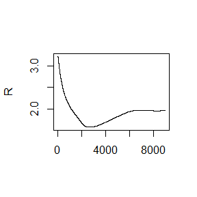

```r
gr <- function(psi) {
  psi <- as.matrix(psi)
  n <- ncol(psi)
  k <- nrow(psi)
  psi.means <- rowMeans(psi)
  B <- n * var(psi.means)
  psi.w <- apply(psi, 1, "var")
  W <- mean(psi.w)
  v.hat <- W*(n-1)/n + (B/n)
  r.hat <- v.hat / W
  return(r.hat)
}

chain <- function(sigma, N, X1) {
  x <- rep(0, N)
  x[1] <- X1
  u <- runif(N)
  for (i in 2:N) {
    xt <- x[i-1]
    y <- rnorm(1, xt, sigma)
    z1 <- f(y,theta) * dnorm(xt, y, sigma)
    z2 <- f(xt,theta) * dnorm(y, xt, sigma)
    if (u[i] <= z1/z2){
      x[i] <- y
    } else {
      x[i] <- xt
      k <- k+1
    }
  }
  return(x)
}

sigma <- 0.5
k <- 4
m <- 10000
b <- 1000
x0 <- c(-10, -5, 5, 10)

set.seed(12345)
X <- matrix(0, nrow=k, ncol=m)
for (i in 1:k){
  X[i, ] <- chain(sigma, m, x0[i])
}

psi <- t(apply(X, 1, cumsum))
for (i in 1:nrow(psi)){
  psi[i,] <- psi[i,] / (1:ncol(psi))
}

rhat <- rep(0, m)
for (j in (b+1):m)
  rhat[j] <- gr(psi[,1:j])
plot(rhat[(b+1):m], type="l", xlab="", ylab="R")
abline(h=1.1, lty=2)
```

9.8:

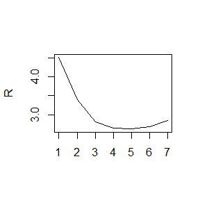

```r
chain2 <- function(a,b,n,N, X1) {
  x10<-X1
  x20<-runif(1,0,1)
  X<-matrix(0, N, 2)
  X[1, ] <- c(x10, x20) #initialize
  for (i in 2:N) {
    x2 <- X[i-1, 2]
    X[i, 1] <- rbinom(1, n, x2)
    x1 <- X[i, 1]
    X[i, 2] <- rbeta(1,x1+a,n-x1+b)
  }
  return(X)
}

N <- 5000
cut <- 1000
X <- matrix(0, N, 2)
a<-2
b<-3
n<-10
k<-4
X10 <- c(-6, -5, 5, 6)


set.seed(12345)
X <- matrix(0, nrow=2*k, ncol=N)
for (i in 1:k)
  X[((2*i-1):(2*i)), ] <- t(chain2(a,b,n, N, X10[i]))

X<-X[c(2,4,6,8),]


psi <- t(apply(X, 1, cumsum))
for (i in 1:nrow(psi))
  psi[i,] <- psi[i,] / (1:ncol(psi))


#plot the sequence of R-hat statistics
rhat <- rep(0, n)
for (j in (b+1):n)
  rhat[j] <- gr(psi[,1:j])
plot(rhat[(b+1):n], type="l", xlab="", ylab="R")
abline(h=1.1, lty=2)
```

#hw8 ## Question Exercises 11.3 (pages 353-354, Statistical Computingwith R)

## Answer

The function $yk$ can calculate the k th :

```r
yk<-function(a,k,d){
  if(k==0){
    y<-exp(log(sum(a*a))-log(2)+lgamma((d+1)/2)+lgamma(k+3/2)-lgamma(k+d/2+1))
  }else{
    y0<-0
    for(i in 1:k){
      y0<-y0+log(i)
    }
    y<-(-1)^k*exp((k+1)*log(sum(a*a))+lgamma((d+1)/2)+lgamma(k+3/2)-y0-k*log(2)-log(2*k+1)-log(2*k+2)-lgamma(k+d/2+1))
  }
  return(y)
}
```

The function $sumyk$ can sum the all number, and gives the result of $a=(1,2)^{T}$:

```r
sumyk<-function(a){
  d<-length(a)
  k0<-10000
  try<-yk(a,k0,d)
  if(try==0){
    k<-k0
  }else{
    k<-k0*10
  }
  s<-0
  for(i in 0:k){
    s<-s+yk(a,i,d)
  }
  return(s)
}

a<-c(1,2)
d<-length(a)
yy<-sumyk(a)
print(yy)
```

```
## [1] 1.532164
```

## Question

Exercises 11.5 (pages 353-354, Statistical Computingwith R)

## Answer

The function $Fun$ can solve $a$:

```r
f1<-function(u,k){
  (1+u^2/(k-1))^(-k/2)
}
f2<-function(u,k){
  (1+u^2/k)^(-(k+1)/2)
}
ff<-function(a,k0){
  k<-k0
  ck0<-((a^2*(k-1))/(k-a^2))^(1/2)
  ck1<-((a^2*k)/(k+1-a^2))^(1/2)
  cc1<-exp(log(2)+lgamma(k/2)-(1/2)*log(pi)-(1/2)*log(k-1)-lgamma((k-1)/2))
  cc2<-exp(log(2)+lgamma(k/2+1/2)-(1/2)*log(pi)-(1/2)*log(k)-lgamma(k/2))
  y01<-integrate(f1,lower=0,upper = ck0, k=k)$value
  y02<-integrate(f2,lower=0,upper = ck1, k=k)$value
  y1<-cc1*y01
  y2<-cc2*y02
  cha<-y1-y2
  return(cha)
}
Fun<-function(k1){
  k<-k1
  a1<-0+0.1
  a2<-2
  ffa1<-ff(a1,k)
  ffa2<-ff(a2,k)
  ffa<-1
  tt<-0
  while(ffa>1e-10){
    med<-(a1+a2)/2
    ffmed<-ff(med,k)
    if(ffa1*ffmed<0){
      a2<-med
    }else{
      a1<-med
    }
    ffa1<-ff(a1,k)
    ffa2<-ff(a2,k)
    a<-med
    ffa<-abs(ff(a,k))
    tt<-tt+1
  }
  return(a)
}
```

$k = 4 : 25, 100, 500, 1000$:

```r
c<-c(c(4:25),100,500,1000)
A<-matrix(0,2,length(c))
A[1,]<-c
for(i in 1:length(c)){
  A[2,i]<-Fun(c[i])
}
A
```

```
##          [,1]     [,2]     [,3]     [,4]     [,5]     [,6]      [,7]      [,8]
## [1,] 4.000000 5.000000 6.000000 7.000000 8.000000 9.000000 10.000000 11.000000
## [2,] 1.492103 1.533559 1.562745 1.584429 1.601182 1.614517  1.625383  1.634409
##           [,9]    [,10]     [,11]     [,12]     [,13]     [,14]     [,15]
## [1,] 12.000000 13.00000 14.000000 15.000000 16.000000 17.000000 18.000000
## [2,]  1.642026  1.64854  1.654174  1.659096  1.663433  1.667283  1.670724
##          [,16]     [,17]     [,18]     [,19]     [,20]     [,21]     [,22]
## [1,] 19.000000 20.000000 21.000000 22.000000 23.000000 24.000000 25.000000
## [2,]  1.673817  1.676614  1.679154  1.681471  1.683594  1.685546  1.687347
##         [,23]      [,24]       [,25]
## [1,] 100.0000 500.000000 1000.000000
## [2,]   1.7206   1.729797    1.730957
```

The relsult is similar with the answer.

## Question 3

Suppose $T_1$, . . . , $T_n$ are i.i.d. samples drawn from the exponential distribution with expectation $\lambda$. Those values greater than τ are not observed due to right censorship, so that the observed values are $Y_i=T_i$ $I(T_i ≤ \tau ) + \tau I(T_i > \tau )$,i = 1, . . . , n. Suppose τ = 1 and the observed $Y_i$ values are as follows: 0.54, 0.48, 0.33, 0.43, 1.00, 1.00, 0.91, 1.00, 0.21, 0.85 Use the E-M algorithm to estimate $\lambda$, compare your result with the observed data MLE (note: $Y_i$ follows a mixture distribution)

## Answer

$L(\lambda)=\prod_{i=1}^n (\lambda e^{-\lambda X_i})^{\delta_i},\delta_i=I(X_i \leqslant \tau)$ $log L(\lambda)= log\lambda \sum_{i=1}^n{\delta_i}-\lambda \sum_{i=1}^n {\delta_i X_i}$， $\lambda = \frac{\sum_{i=1}^n{\delta_i}}{{\sum_{i=1}^n {\delta_i X_i}}}$

#hw9 ## Question 1 1. Why are the following two invocations of lapply() equivalent? trims <- c(0, 0.1, 0.2, 0.5) x <- rcauchy(100) lapply(trims, function(trim) mean(x, trim = trim)) lapply(trims, mean, x = x)

## Answer

```r
trims <- c(0, 0.1, 0.2, 0.5)
x <- rcauchy(100)
lapply(trims, function(trim) mean(x, trim = trim))
```

```
## [[1]]
## [1] 5.307202
##
## [[2]]
## [1] 0.3967458
##
## [[3]]
## [1] 0.2086344
##
## [[4]]
## [1] 0.3277702
```

```r
lapply(trims, mean, x = x)
```

```
## [[1]]
## [1] 5.307202
##
## [[2]]
## [1] 0.3967458
##
## [[3]]
## [1] 0.2086344
##
## [[4]]
## [1] 0.3277702
```

第一个语句：对向量trims每一个元素都运行函数，这个函数是求去掉排序后两端trim*n个观测值计算剩余均值 第二个语句：x=x表示函数mean计算的数列是x,mean中trim参数值取向量trims的元素

## Question 2

5. For each model in the previous two exercises, extract R2 using the function below. rsq <- function(mod) summary(mod)$r.square

## Answer

将函数用于第3题

```r
formulas <-list(
  mpg ~ disp,
  mpg ~I(1/ disp),
  mpg ~ disp + wt,
  mpg ~I(1/ disp) + wt
)
for(i in 1:4){
  lm(formulas[[i]],mtcars)
}
Mod1<-lapply(formulas,lm,data=mtcars)
rsq <- function(mod)summary(mod)$r.squared
lapply(Mod1,rsq)
```

```
## [[1]]
## [1] 0.7183433
##
## [[2]]
## [1] 0.8596865
##
## [[3]]
## [1] 0.7809306
##
## [[4]]
## [1] 0.8838038
```

```r
bootstraps <-lapply(1:10, function(i) {
  rows <-sample(1:nrow(mtcars),rep =TRUE)
  mtcars[rows, ]
})
Mod2<-lapply(bootstraps,lm,mtcars)
rsq <- function(mod)summary(mod)$r.squared
lapply(Mod2,rsq)
```

```
## [[1]]
## [1] 0.8690158
##
## [[2]]
## [1] 0.8690158
##
## [[3]]
## [1] 0.8690158
##
## [[4]]
## [1] 0.8690158
##
## [[5]]
## [1] 0.8690158
##
## [[6]]
## [1] 0.8690158
##
## [[7]]
## [1] 0.8690158
##
## [[8]]
## [1] 0.8690158
##
## [[9]]
## [1] 0.8690158
##
## [[10]]
## [1] 0.8690158
```

## Question 3

1. Use vapply() to:
1. Compute the standard deviation of every column in a numeric data frame.
2. Compute the standard deviation of every numeric column in a mixed data frame. (Hint: you’ll need to use vapply() twice.)

## Answer

1(a):

```r
x1<-data.frame(rnorm(20),runif(20))
vapply(x1,sd,numeric(1))
```

```
## rnorm.20. runif.20.
## 0.9281025 0.2816383
```

1(b):

```r
x2 <- list(a = c(1:10), beta = exp(-3:3),ogic = c(TRUE,FALSE,FALSE,TRUE))
vapply(x2,sd,numeric(1))
```

```
##         a      beta      ogic
## 3.0276504 7.3325826 0.5773503
```

## Question 4

7. Implement mcsapply(), a multicore version of sapply(). Can you implement mcvapply(), a parallel version of vapply()? Why or why not?

## Answer

```r
library(parallel)
boot_df <- function(x) x[sample(nrow(x),rep =T), ]
rsquared <- function(mod)summary(mod)$r.square
boot_lm <- function(i) {
  rsquared(lm(mpg ~ wt + disp,data =boot_df(mtcars)))
}
system.time(mclapply(1:500, boot_lm,mc.cores =2))
```

[output not shown]

mcvapply():

```r
mcvapply<-function (X, FUN, ..., mc.preschedule = TRUE, mc.set.seed = TRUE,
          mc.silent = FALSE, mc.cores = 1L, mc.cleanup = TRUE, mc.allow.recursive = TRUE,
          affinity.list = NULL)
{
  cores <- as.integer(mc.cores)
  if (cores < 1L)
    stop("'mc.cores' must be >= 1")
  if (cores > 1L)
    stop("'mc.cores' > 1 is not supported on Windows")
  vapply(X, FUN, ...)
}
```

#hw10 ## Question 1 Write an Rcpp function for Exercise 9.8 (page 278, Statistical Computing with R).

## Answer

Rcpp function：

```r
#include <Rcpp.h>
#using namespace Rcpp;

#// [[Rcpp::export]]
#NumericMatrix fun98( int a,int b,int N) {
#  NumericMatrix x(N, 2);
#  double x1 = 0, x2 = 0;
#  double t1 = 0, t2 = 0;

#  for(int i = 1; i < N; i++) {
#    x2=x(i-1,1);
#    t1=rbinom(1,25,x2)[0];
#    x(i,0)=t1;
#    x1=x(i,0);
#    t2=rbeta(1,x1+a,25-x1+b)[0];
#    x(i,1)=t2;
#  }
#  return(x);
#}
```

```r
#library(Rcpp)
#dir_cpp <- 'D:/Rcpp/'
# Can create source file in Rstudio
#sourceCpp(paste0(dir_cpp,"1cpp.cpp"))
#a <- 1
#b <- 1
#N <- 10000


#X1<-fun98(a,b,N)
#plot(X1[,1],X1[,2],xlab = "x",ylab = "y")
```

```r
#a <- 1
#b <- 1
#N <- 10000


#X <- matrix(0, N, 2)
#X[1,] <- c(0,0.5)
#for(i in 2:N){
#  X2 <-  X[i-1, 2]
#  X[i,1] <- rbinom(1,25,X2)
#  X1 <- X[i,1]
#  X[i,2] <- rbeta(1,X1+a,25-X1+b)
#}
#plot(X[,1],X[,2],xlab = "x",ylab = "y")
```

## Question 2

Compare the corresponding generated random numbers with pure R language using the function “qqplot”.

## Answer

betasjs:

```r
#betasjs<-function(n,a,b){
#  X <- rchisq(n, 2 * a, ncp = 0)
#  sjs<-X/(X + rchisq(n, 2 * b))
#  return(sjs)
#}
#n<-500
#a<-2
#b<-3
#x1<-betasjs(n,a,b)
#x2<-rbeta(n,a,b)
#qqplot(x1,x2)
```

## Question 3

Campare the computation time of the two functions with the function “microbenchmark”.

## Answer

Compare with microbenchmark:

```r
#library(microbenchmark)
#n<-500
#a<-2
#b<-3
#ts <- microbenchmark(x1=betasjs(n,a,b),x2=rbeta(n,a,b))
#summary(ts)[,c(1,3,5,6)]
```

## Question 4

Comments your results.